# Economical consequences of storms in the United States

## Synopsis

The weather event data originated from the National Environmental Satellite, Data, and Information Service (NESDIS). The weather events were classified into valid events using a string pattern matching algorithm. Further information is given in section **Data Processing**. With the algorithm the total number of weather events was reduced from originally 977 to 20. The total number of deaths, injuries and costs is used as metric to incorporate both, the number of events and their respective magnitude. Thus mild weather events which appear on a common basis are weighted similar to severe events which only happen rarely. The most dangeraous wether events are tornados, heat and floods accounting to 66% of all observed deaths in the United States. Furthermore, 63% of all injuries are caused by tornados. Wind, tornados, floods, thunderstorms amd hail cause the most economic damage accounting to almost 90% of total costs.

## Data Processing

```r
storm <- read_csv("data/repdata_data_StormData.csv") %>%
  select(EVTYPE, FATALITIES, INJURIES, PROPDMG, CROPDMG)
```

is applied. Thus complex events like **flash flood - heavy wind** are assigned to multiple valid events e.g. **flood** and **wind**. If none of the event strings match with any of the valid events the valid event **other** was assigned.

```r
rep(1:nrow(data), times = nids)
```

[output not shown]

[output cut: 18 more lines]

```r
# Classification is very time consuming. The classified data is stored in storm_clean.Rda
storm_clean <- classify_events(storm)
save(storm_clean, file = "storm_clean.rda")
```

```r
load(file = "storm_clean.rda", verbose = TRUE)
```

```
Loading objects:
  storm_clean
```

The number of events has been reduced to 20.

## Results

The total number of deaths and injuries is used as metric to incorporate both, the number of deaths per event and the total number of events. Thus events with a small number of deaths which happen on a regular basis e.g. **heat** are weighted similar to severe events which only happen in rare cases.

```r
rev(as.character(deaths$valid_event[top3]))
```

```
[1] "tornado" "heat"    "flood"
```

[figure not shown]

63 % of all injuries due to weather events are caused by tornado.

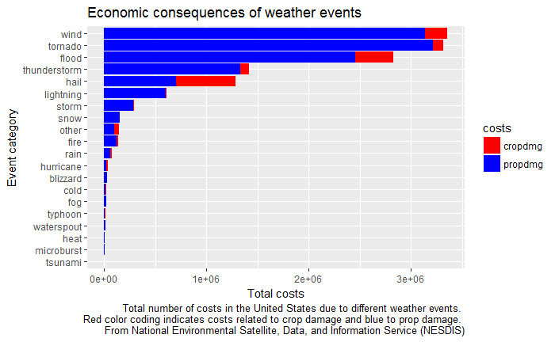

```r
top3_cost
```

[output not shown]

The weather events causing the most economic consequences are wind, tornado, flood, thunderstorm, hail. Together they account to 89% of all costs. Prop related damage is much higher compared to crop related damage.